# DS400: Assignment V (R)

Janik Müller (Student ID: 6303477) - worked together with Christopher Forschner and Simon Andres

2023-01-31

### Setting up a new GitHub repository

1. Register on github.com in case you have not done this already.
2. Initialize a new public repository for this assignment on GitHub.
3. For the following exercises of this assignment, follow the standard Git workflow (i.e., pull the latest version of the project to your local computer, then stage, commit, and push all the modifications that you make throughout the project). Every logical programming step should be well documented on GitHub with a meaningful commit message, so that other people (e.g., your course instructor) can follow and understand the development history. You can do this either using Shell commands or a Git GUI of your choice.

4.In the HTML file that you submit, include the hyperlink to the project repository (e.g., https://github. com/yourUserName/yourProjectName)

```r
git_repository_url <- "https://github.com/Janik298/DS400-Assignment_V-.git"
```

### Preparing the environment

Before starting with this exercise we are loading all necessary packages into our environment.

```r
# Loading the packages
library(jsonlite)
library(httr)
library(tidyverse)
library(rlist)
```

### Getting to know the API

5.Visit the documentation website for the API provided by ticketmaster.com (see here). Familiarize yourself with the features and functionalities of the Ticketmaster Discovery API. Have a particular look at rate limits.

Features of the API: - The default quota is 5000 API calls per day and rate limitation of 5 requests per second. - Deep Paging: we only support retrieving the 1000th item. i.e. ( size * page < 1000) - Root URL: https://app.ticketmaster.com/discovery/v2/ - Event Search is possible via latitude and longitude with “latlong” - however they say one should you “geoPoint” instead - Overall a lot of information is provided by the API

6. Whithin the scope of this assignment, you do not have to request your own API key. Instead retrieve a valid key from the API Explorer. This API key enables you to perform the GET requests needed throughout this assignment. Even though this API key is not secret per se (it is publicly visible on the API Explorer website), please comply to the common secrecy practices discussed in the lecture and the tutorial: Treat the API key as a secret token. Your API key should neither appear in the code that you are submitting nor in your public GitHub repository.

```r
source('api_key.R')
```

### Interacting with the API - the basics

7.Perform a first GET request, that searches for event venues in Germany (countryCode = “DE”). Extract the content from the response object and inspect the resulting list. Describe what you can see.

```r
# Make a first request to get the event venues in Germany

event_venues_de <- GET("https://app.ticketmaster.com/discovery/v2/venues",
                        query = list("apikey" = api_key,
                                "countryCode" = "DE",
                                "locale" = "*",
                                "size" = 20)) %>% content # directly extracting the contents

# With the size argument I can choose the page size of the response

# Extracting the Content to

total_elements <- event_venues_de$page$totalElements
size <- event_venues_de$page$size
total_Pages <- event_venues_de$page$totalPages
number <- event_venues_de$page$number

data.frame(total_elements, size, total_Pages, number)
```

```
##   total_elements size total_Pages number
## 1          12936   20         647      0
```

8. Extract the name, the city, the postalCode and address, as well as the url and the longitude and latitude of the venues to a data frame. This data frame should have the following structure:

```r
# Extracting the wanted items
venues_de <- event_venues_de$`_embedded`$venues # this is a list containing all the venues (at least the first page)

venues_de_df <- map(.x = venues_de, as.data.frame) %>% # I now have transformed the the sublists into dataframes
                bind_rows() %>% # We now have a dataframe containing all information, but in an untidy way
                select(name, city = name.1, postal_code = postalCode, address = line1, url, longitude = location.longitude, latitude = location.latitude)
```

### Interacting with the API - advanced

9. Have a closer look at the list element named page. Did your GET request from exercise (7) return all event locations in Germany? Obviously not - there are of course much more venues in Germany than those contained in this list. Your GET request only yielded the first results page containing the first 20 out of several thousands of venues. Check the API documentation under the section Venue Search. How can you request the venues from the remaining results pages? Iterate over the results pages and perform GET requests for all venues in Germany. After each iteration, extract the seven variables name, city, postalCode, address, url, longitude, and latitude. Join the information in one large data frame. Print the first 10 rows and the shape of the resulting data frame. The resulting data frame should look something like this (note that the exact number of search results may have changed since this document has been last modified):

The venue search shows us that we can specify the number of entries contained on one page and that we can specify which page we want to look at. With this information we can design a function in combination with a loop which will get the data and also tidy it.

```r
## First we are going to write a function that will perform the get request and adheres to the rate limit

worker <- function(page){
    # Setting the rate Limit
          Sys.sleep(0.3)
    # Building the request and specifying everything but the pages
      venues <- GET('https://app.ticketmaster.com/discovery/v2/venues',
                     query = list("apikey" = api_key,
                                 "countryCode" = "DE",
                                 "locale" = "*",
                                 "page" = page,
                                 "size" = 199)) # total elements are 12935 which is just 65*199 -> set the size to 199 to get only full pages


      # Return the Information
      return(content(venues)$`_embedded`$venues)
}


## Requesting the data (Attention: pages are zero indexed)

# First making a small request to check the number of pages that I have to iterate over

test <- GET("https://app.ticketmaster.com/discovery/v2/venues",
                        query = list("apikey" = api_key,
                                "countryCode" = "DE",
                                "locale" = "*",
                                "page" = 64,
                                "size" = 199)) %>% content # directly extracting the contents



# I need to go over 65 pages

all_venues_de <- map(.x = 0:64, .f = worker) # this is now a list which contains sublists that contain the data we are interested in


## Creating a Data-Frame out of the lists

all_venues_de_df <- tibble()
temp <- tibble()

for (i in 1:64) {
    temp <- map(.x = all_venues_de[[i]], as.data.frame) %>%
                bind_rows() %>%
                select(name, city = name.1, postal_code = postalCode, address = line1, url, longitude = location.longitude, latitude = location.latitude)

    all_venues_de_df <- rbind(all_venues_de_df, temp)
}



# There is a problem with the last page which I am going to fix by hand:
last_page <- all_venues_de[[65]]

temp_1 <- tibble()

for (i in 1:36) {
    temp_1 <- as.data.frame(last_page[[i]])

    all_venues_de_df <- bind_rows(all_venues_de_df, temp_1)

}


# I was not able to solve this problem completely, somehow the last page is not convertible into a data-frame. I will leave them out and calculate with the data that I have.

all_venues_de_df <- all_venues_de_df %>% select(name, city, postal_code, address, url, longitude, latitude) %>% mutate(longitude = as.numeric(longitude), latitude = as.numeric(latitude))

## First 10 Rows

head(all_venues_de_df, n = 10)
```

```
##                        name         city postal_code               address
## 1        Grosse Freiheit 36      Hamburg       22767    Grosse Freiheit 36
## 2                 Gruenspan      Hamburg       22767    Grosse Freiheit 58
## 3         Huxleys Neue Welt       Berlin       10967  Hasenheide 107 – 113
## 4           Zentrum am Park Emmelshausen       56281 Rhein-Mosel-Straße 45
## 5  Stadthalle (Theatersaal)      Mülheim       45479 Theodor-Heuss-Platz 1
## 6             Schlossgarten     Bruchsal       76646      Schloss Bruchsal
## 7                Stadthalle   Hockenheim       68766       Rathausstraße 3
## 8                       FZW     Dortmund       44263       Ritterstraße 20
## 9               Arena Trier        Trier       54292    Fort-Worth-Platz 1
## 10            Eissporthalle    Memmingen       87700   Hühnerbergstraße 19
##                                                                                         url
## 1                                                   http://www.ticketmaster.de/venue/287636
## 2                                                   http://www.ticketmaster.de/venue/287155
## 3                                                   http://www.ticketmaster.de/venue/286842
```

[output cut: 18 more lines]

```r
## Shape of the Data Frame

dim(all_venues_de_df)
```

```
## [1] 12772     7
```

### Visualizing the extracted data

10. Below, you can find code that produces a map of Germany. Add points to the map indicating the locations of the event venues across Germany.

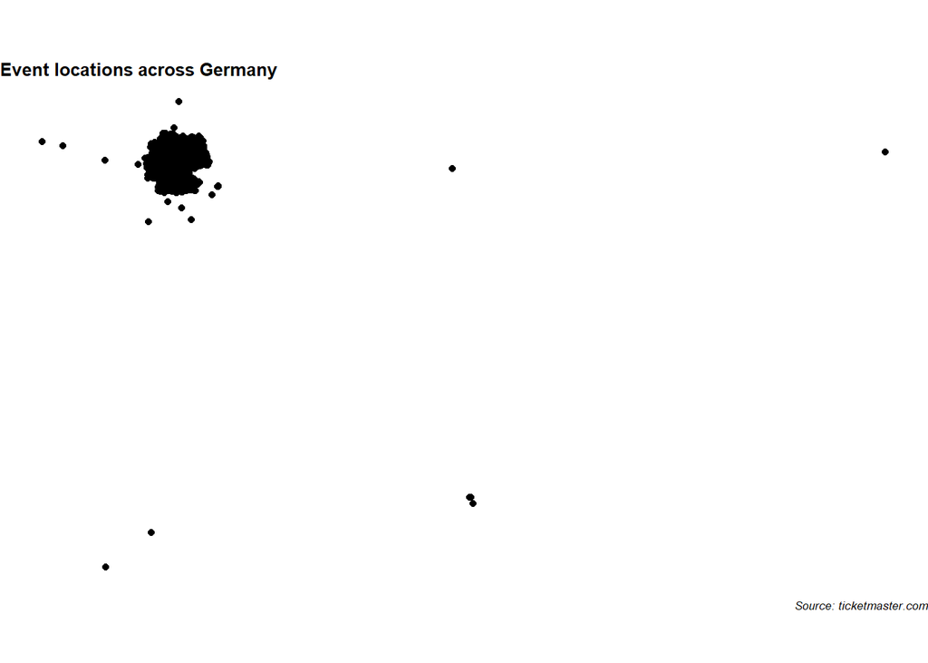

```r
ggplot(data = all_venues_de_df) +
    borders("world", "Germany", colour = "black", fill = "grey90") +
    theme_void() +
    coord_quickmap() +
    geom_point(mapping = aes(x = longitude, y = latitude)) +
    labs(title = "Event locations across Germany",
         caption = "Source: ticketmaster.com") +
    theme(title = element_text(size = 8, face = 'bold'),
          plot.caption = element_text(face = "italic"))
```

11. You will find that some coordinates lie way beyond the German borders and can be assumed to be faulty. Set coordinate values to NA where the value of longitude is outside the range (5.866, 15.042) or where the value of latitude is outside the range (47.270, 55.059) (these coordinate ranges have been derived from the extreme points of Germany as listed on Wikipedia (see here). For extreme points of other countries, see here).

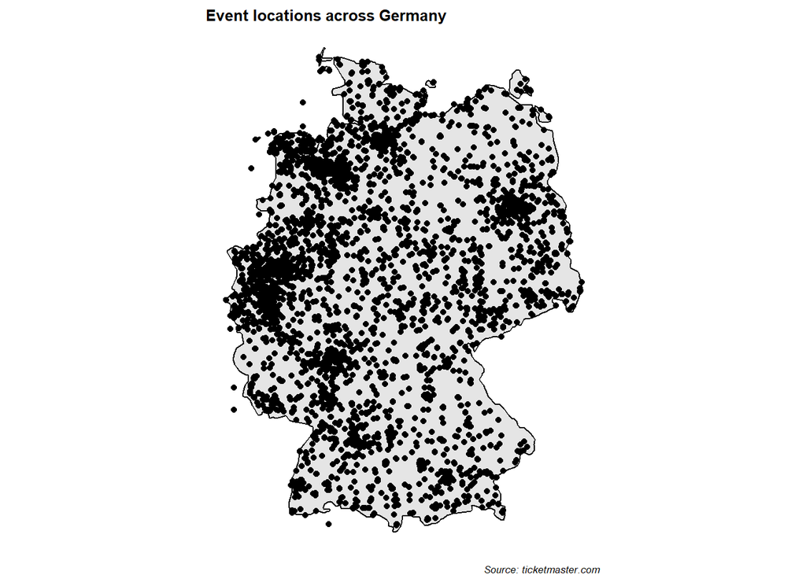

```r
# Filtering for the right latitude and longitude

all_venues_de_df <- all_venues_de_df %>% filter(longitude < 15.042 & longitude > 5.866) %>% filter(latitude > 47.270 & latitude < 55.059)


ggplot(data = all_venues_de_df) +
    borders("world", "Germany", colour = "black", fill = "grey90") +
    theme_void() +
    coord_quickmap() +
    geom_point(mapping = aes(x = longitude, y = latitude)) +
    labs(title = "Event locations across Germany",
         caption = "Source: ticketmaster.com") +
    theme(title = element_text(size = 8, face = 'bold'),
          plot.caption = element_text(face = "italic"))
```

### Event locations in other countries

12. Repeat exercises (9)–(11) for another European country of your choice. (Hint: Clean code pays off! If you have coded the exercises efficiently, only very few adaptions need to be made.)

```r
## I will do Luxembourg since this is where I am from

venues_lu <- GET('https://app.ticketmaster.com/discovery/v2/venues',
                     query = list("apikey" = api_key,
                                 "countryCode" = "LU",
                                 "locale" = "*",
                                 "size" = 102)) %>% content()

# Creating a DataFrame

venues_lu_df <- map(venues_lu$`_embedded`$venues, .f = as.data.frame) %>% bind_rows() %>% select(name, city = name.1, postal_code = postalCode, address = line1, url, longitude = location.longitude, latitude = location.latitude) %>% mutate(longitude = as.numeric(longitude), latitude = as.numeric(latitude))


# First 10 Rows

head(venues_lu_df, n = 10)
```

```
##                   name              city postal_code                   address
## 1  The Floor (Rockhal)  Esch-sur-Alzette        4361  Avenue du Rock'n'Roll, 5
## 2     Parc Gaalgebierg  Esch-sur-Alzette      L-4142              Rue du Stade
## 3          Rockhal Box  Esch-sur-Alzette        4361  Avenue du Rock'n'Roll, 5
## 4    Rockhal Main Hall  Esch-sur-Alzette        4361  Avenue du Rock'n'Roll, 5
## 5         Rockhal Club  Esch-sur-Alzette        4361  Avenue du Rock'n'Roll, 5
## 6         Philharmonie   Luxembourg-City      L-1499      Place de l'Europe, 1
## 7          Herchesfeld  Roeser-Luxemburg        3206                    Roeser
## 8     Château Beaufort          Beaufort      L-6313            Rue du Château
## 9              Rockhal  Esch-sur-Alzette        4361 Avenue du Rock''n''Roll 5
## 10         Casino 2000 Mondorf-Les-Bains      L-5618     rue Théodore Flammang
##                                                                                      url
## 1  https://www.ticketmaster.be/venue/the-floor-rockhal--esch-sur-alzette-tickets/rfl/101
## 2    https://www.ticketmaster.be/venue/parc-gaalgebierg-esch-sur-alzette-tickets/gal/101
## 3         https://www.ticketmaster.be/venue/rockhal-box-esch-sur-alzette-tickets/rbx/101
```

[output cut: 18 more lines]

```r
#Dimensions of the Data Frame
dim(venues_lu_df)
```

```
## [1] 102   7
```

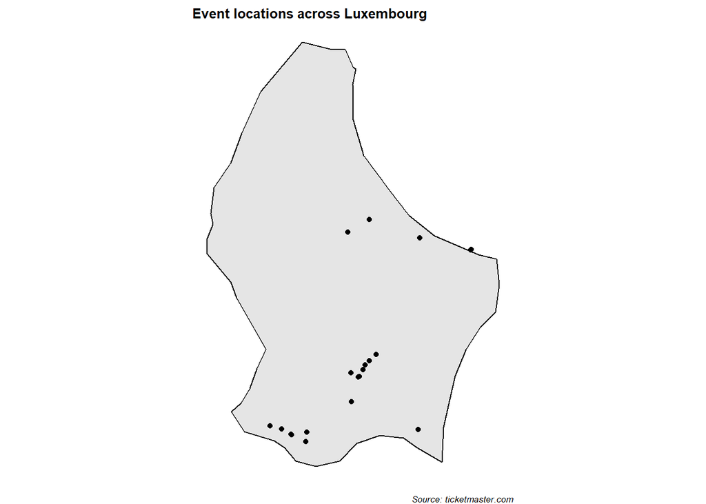

```r
## Plotten

ggplot(data = venues_lu_df) +
    borders("world", "Luxembourg", colour = "black", fill = "grey90") +
    theme_void() +
    coord_quickmap() +
    geom_point(mapping = aes(x = longitude, y = latitude)) +
    labs(title = "Event locations across Luxembourg",
         caption = "Source: ticketmaster.com") +
    theme(title = element_text(size = 8, face = 'bold'),
          plot.caption = element_text(face = "italic"))
```

```r
# there were no Plces outside the luxembourgish Borders
```

### Event locations in other countries - Again

12. Repeat exercises (9)–(11) for another European country of your choice. (Hint: Clean code pays off! If you have coded the exercises efficiently, only very few adaptions need to be made.)

We are going to do: Belgium

```r
## First we are going to write a function that will perform the get request and adheres to the rate limit

worker_be <- function(page){
    # Setting the rate Limit
          Sys.sleep(0.3)
    # Building the request and specifying everything but the pages
      venues <- GET('https://app.ticketmaster.com/discovery/v2/venues',
                     query = list("apikey" = api_key,
                                 "countryCode" = "BE",
                                 "locale" = "*",
                                 "page" = page,
                                 "size" = 20))


      # Return the Information
      return(content(venues)$`_embedded`$venues)
}


## Requesting the data (Attention: pages are zero indexed)

# First making a small request to check the number of pages that I have to iterate over

test <- GET("https://app.ticketmaster.com/discovery/v2/venues",
                        query = list("apikey" = api_key,
                                "countryCode" = "BE",
                                "locale" = "*",
                                "page" = 0,
                                "size" = 20)) %>% content # directly extracting the contents



# I need to go over 56 pages

temp_be <- tibble()
venues_be_df <- tibble()

venues_be <- map(.x = 0:55, .f = worker_be)
## Creating a Data-Frame out of the lists

for (i in 1:56) {

    temp_be <- map(.x = venues_be[[i]], as.data.frame) %>%
                bind_rows()

    venues_be_df <- bind_rows(venues_be_df, temp_be)
}

venues_be_df <- venues_be_df %>% select(name, city = name.1, postal_code = postalCode, address = line1, url, longitude = location.longitude, latitude = location.latitude)


venues_be_df <- venues_be_df %>% select(name, city, postal_code, address, url, longitude, latitude) %>% mutate(longitude = as.numeric(longitude), latitude = as.numeric(latitude))

## First 10 Rows

head(venues_be_df, n = 10)
```

```
## # A tibble: 10 × 7
##    name                       city  postal_code address url   longitude latitude
##    <chr>                      <chr> <chr>       <chr>   <chr>     <dbl>    <dbl>
##  1 Site du festival           Bert… 6880        Place … http…      5.25     49.9
##  2 Musée des Instruments de … Brus… 1000        Montag… http…      4.36     50.8
##  3 La Madeleine               Brus… 1000        Rue Du… http…      4.35     50.8
##  4 Grand-Place of Brussels    Brus… 1000        Entran… http…      4.35     50.8
##  5 Abbaye de Villers-la-Ville Vill… 1495        Rue de… http…      4.53     50.6
##  6 Dôme                       Char… 6000        Rue de… http…      4.45     50.4
##  7 Le Palace (MCATH)          Ath   7800        Rue de… http…      3.78     50.6
##  8 Site Ecolys                Namur 5020        Avenue… http…      4.80     50.5
##  9 Caserne Fonck              Liège 4020        Rue Ra… http…      5.59     50.6
## 10 Centre Culturel            Sera… 4100        Rue Re… http…      5.50     50.6
```

```r
## Shape of the Data Frame

dim(venues_be_df)
```

```
## [1] 1113    7
```

[figure not shown]

```r
## Now we are Plotting

ggplot(data = venues_be_df) +
    borders("world", "Belgium", colour = "black", fill = "grey90") +
    theme_void() +
    coord_quickmap() +
    geom_point(mapping = aes(x = longitude, y = latitude)) +
    labs(title = "Event locations across Germany",
         caption = "Source: ticketmaster.com") +
    theme(title = element_text(size = 8, face = 'bold'),
          plot.caption = element_text(face = "italic"))
```

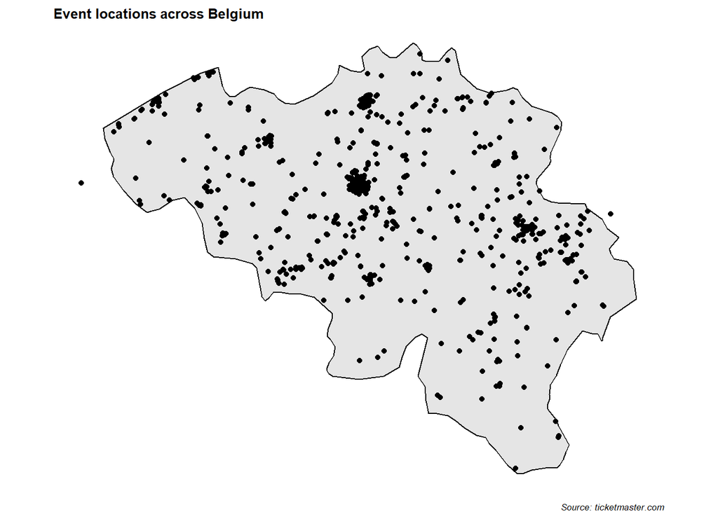

```r
## Filtering for the right latitude and longitude

venues_be_df <- venues_be_df %>% filter(longitude < 6.3831 & longitude > 2.35) %>% filter(latitude > 49.5072 & latitude < 51.4978)


ggplot(data = venues_be_df) +
    borders("world", "Belgium", colour = "black", fill = "grey90") +
    theme_void() +
    coord_quickmap() +
    geom_point(mapping = aes(x = longitude, y = latitude)) +
    labs(title = "Event locations across Belgium",
         caption = "Source: ticketmaster.com") +
    theme(title = element_text(size = 8, face = 'bold'),
          plot.caption = element_text(face = "italic"))
```